# Tugas 6 dan 7

Gladys Adya Zafira

2023-10-16

## Diagnostik dan Peramalan

### Libraries

```r
library(ggplot2)
library(tsibble)
library(tseries)
library(MASS)
library(forecast)
library(TSA)
library(TTR)
library(aTSA)
library(graphics)
```

### Input Data

```r
data<-rio::import("https://raw.githubusercontent.com/gladysadyaz/mpdw/main/Data/SPOT.csv")

#Mengganti tipe data menjadi time series
dataclose.ts<-ts(data$Close)
```

### Eksplorasi Data

### Plot Data Keseluruhan

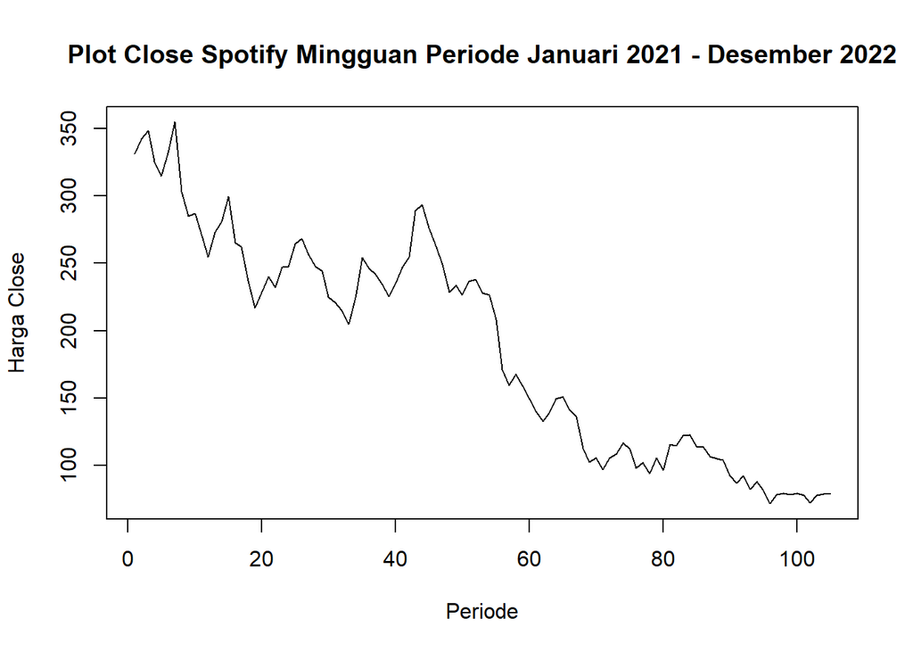

```r
plot.ts(dataclose.ts, xlab="Periode", ylab="Harga Close", main="Plot Close Spotify Mingguan Periode Januari 2021 - Desember 2022")
```

### Plot Data Train

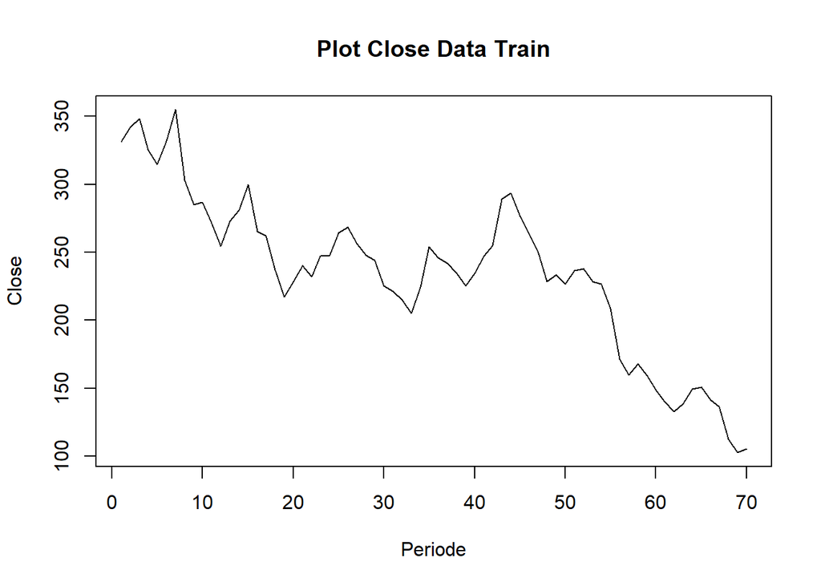

```r
datatrain<-data$Close[1:70]
train.ts<-ts(datatrain)
plot.ts(train.ts, lty=1, xlab="Periode", ylab="Close", main="Plot Close Data Train")
```

Plot data train mengindikasikan data tidak stasioner dalam rataan maupun ragam

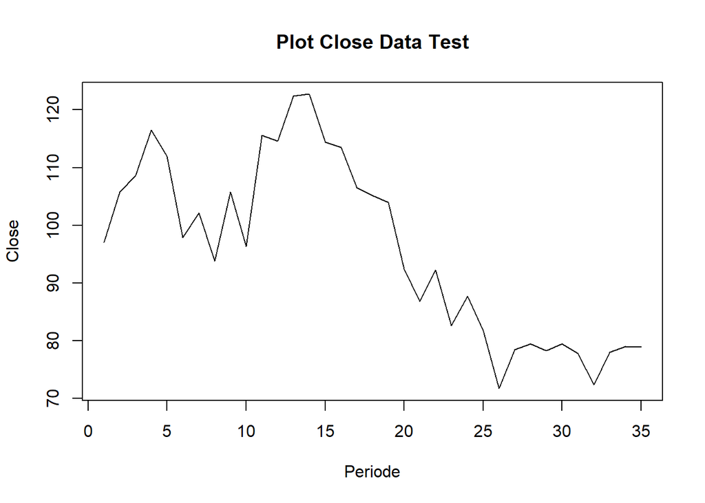

```r
datatest<-data$Close[71:105]
test.ts<-ts(datatest)
plot.ts(test.ts, lty=1, xlab="Periode", ylab="Close", main="Plot Close Data Test")
```

Plot data test mengindikasikan data tidak stasioner dalam rataan maupun ragam. Selanjutnya akan dilihat sifat stasioner data train melalui plot ACF, Uji ADF, dan plot Box-Cox

### Kestasioneran Data

### Plot ACF

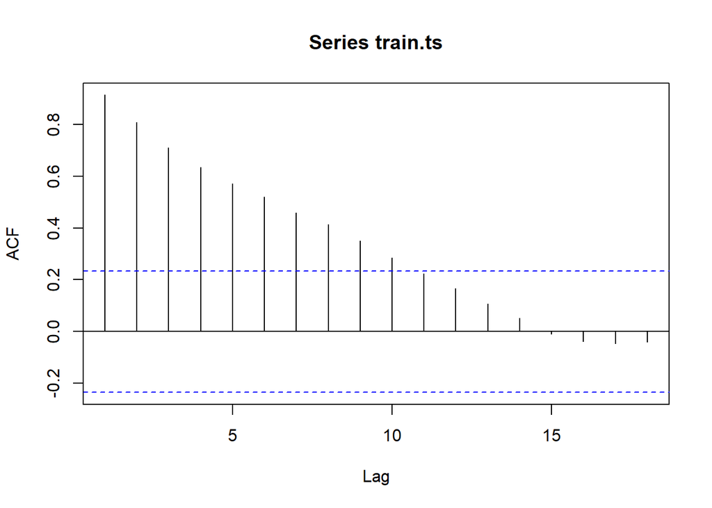

```r
acf(train.ts)
```

Plot ACF di atas menampilkan bahwa data menurun secara perlahan atau tails off slowly, artinya data diindikasi tidak stasioner dalam rataan.

### Uji ADF

H0: Data tidak stasioner dalam rataan H1: Data stasioner dalam rataan

```r
tseries::adf.test(train.ts)
```

```
##
##  Augmented Dickey-Fuller Test
##
## data:  train.ts
## Dickey-Fuller = -1.7314, Lag order = 4, p-value = 0.6845
## alternative hypothesis: stationary
```

Berdasarkan hasil uji ADF, diperoleh p-value sebesar 0.6845 > 0.05. Hal ini menunjukkan keputusan terima H0, artinya data tidak stasioner dalam rataan. Hasil ini sesuai dengan hasil yang diperoleh ketika melalukan eksplorasi dengan plot time series serta plot ACF.

### Plot Box-Cox

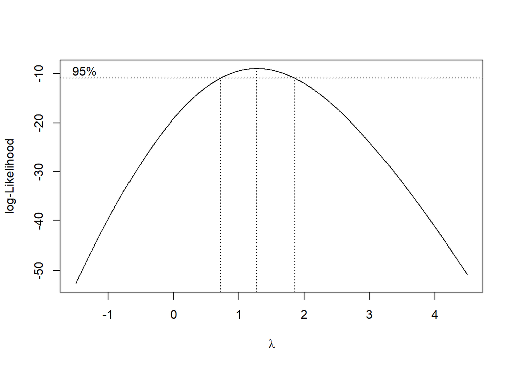

```r
index <- seq(1:70)
bc = boxcox(train.ts~index, lambda = seq(-1.5,4.5,by=0.01))
```

```r
#Nilai Rounded Lambda
lambda <- bc$x[which.max(bc$y)]
lambda
```

```
## [1] 1.27
```

```r
#SK
bc$x[bc$y > max(bc$y) - 1/2 * qchisq(.95,1)]
```

```
##   [1] 0.72 0.73 0.74 0.75 0.76 0.77 0.78 0.79 0.80 0.81 0.82 0.83 0.84 0.85 0.86
##  [16] 0.87 0.88 0.89 0.90 0.91 0.92 0.93 0.94 0.95 0.96 0.97 0.98 0.99 1.00 1.01
##  [31] 1.02 1.03 1.04 1.05 1.06 1.07 1.08 1.09 1.10 1.11 1.12 1.13 1.14 1.15 1.16
##  [46] 1.17 1.18 1.19 1.20 1.21 1.22 1.23 1.24 1.25 1.26 1.27 1.28 1.29 1.30 1.31
##  [61] 1.32 1.33 1.34 1.35 1.36 1.37 1.38 1.39 1.40 1.41 1.42 1.43 1.44 1.45 1.46
##  [76] 1.47 1.48 1.49 1.50 1.51 1.52 1.53 1.54 1.55 1.56 1.57 1.58 1.59 1.60 1.61
##  [91] 1.62 1.63 1.64 1.65 1.66 1.67 1.68 1.69 1.70 1.71 1.72 1.73 1.74 1.75 1.76
## [106] 1.77 1.78 1.79 1.80 1.81 1.82 1.83 1.84
```

Plot Boxcox menunjukkan nilai lambda (λ) optimum sebesar 1.27. Pada selang kepercayaan 95% nilai memiliki batas bawah 0.72 dan batas atas 1.84. Selang tersebut memuat nilai satu sehingga dapat dikatakan bahwa data yang digunakan stasioner dalam ragam

### Penanganan Ketakstasioneran Data

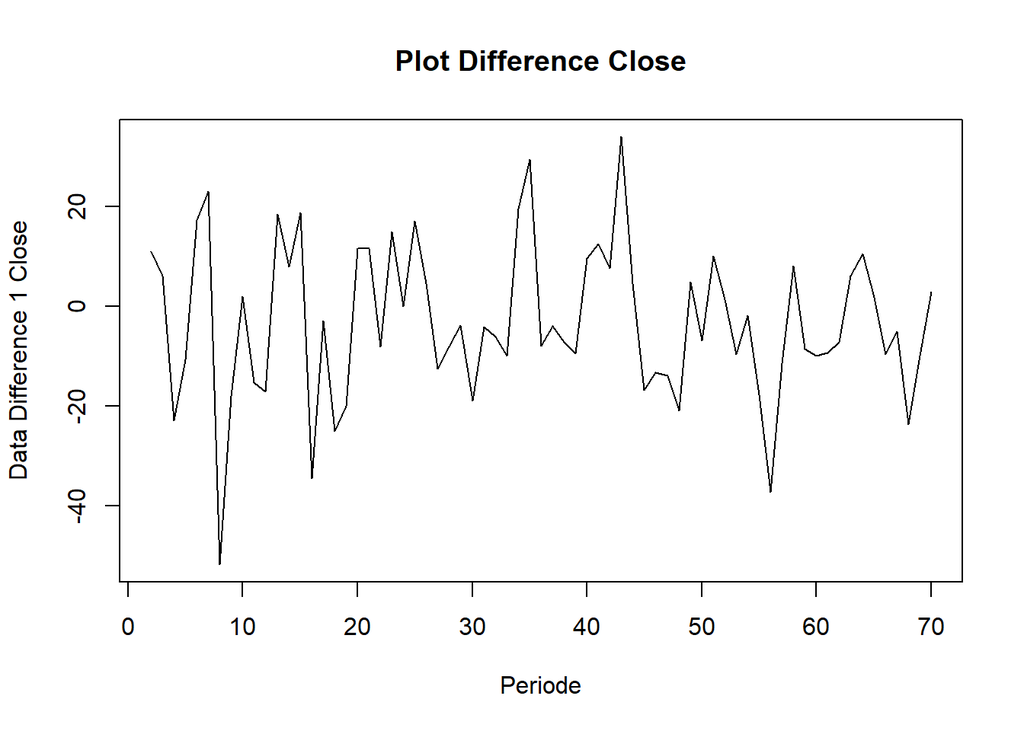

```r
train.diff1<-diff(train.ts,differences = 1)
plot.ts(train.diff1, lty=1, xlab="Periode", ylab="Data Difference 1 Close", main="Plot Difference Close")
```

Terlihat bahwa data cenderung telah stasioner dalam rataan. Selanjutnya akan dilakukan uji kestasioneran data menggunakan plot ACF dan Uji ADF.

### Plot ACF

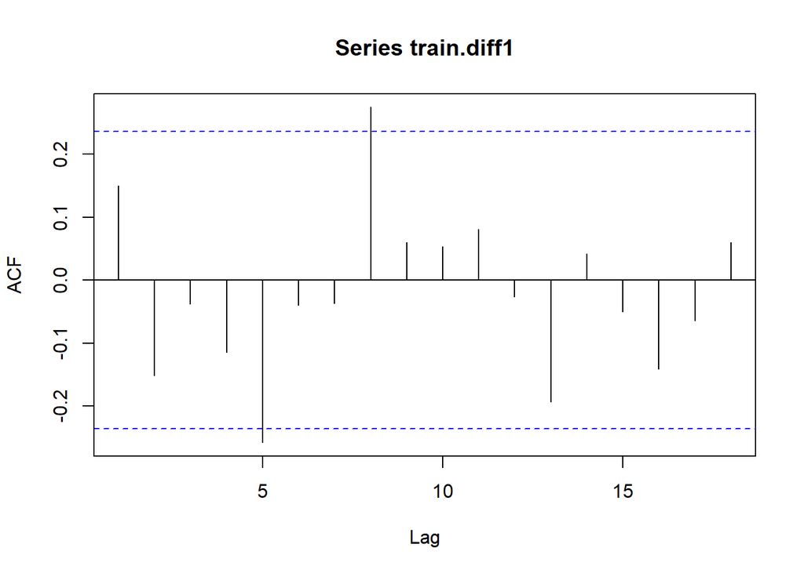

```r
acf(train.diff1)
```

Terlihat bahwa data tidak lagi menurun secara perlahan. Hal ini menunjukkan data telah stasioner dalam rataan

### Uji ADF

H0: Data tidak stasioner dalam rataan H1: Data stasioner dalam rataan

```r
tseries::adf.test(train.diff1)
```

```
##
##  Augmented Dickey-Fuller Test
##
## data:  train.diff1
## Dickey-Fuller = -5.0197, Lag order = 4, p-value = 0.01
## alternative hypothesis: stationary
```

Berdasarkan hasil uji ADF, diperoleh p-value sebesar 0.01 < 0.05. Hal ini menunjukkan keputusan tolak H0, artinya data stasioner dalam rataan. Kestidakstasioneran data telah tertangani, selanjutnya akan dilakukan identifikasi model

### Identifikasi Model

### Plot ACF

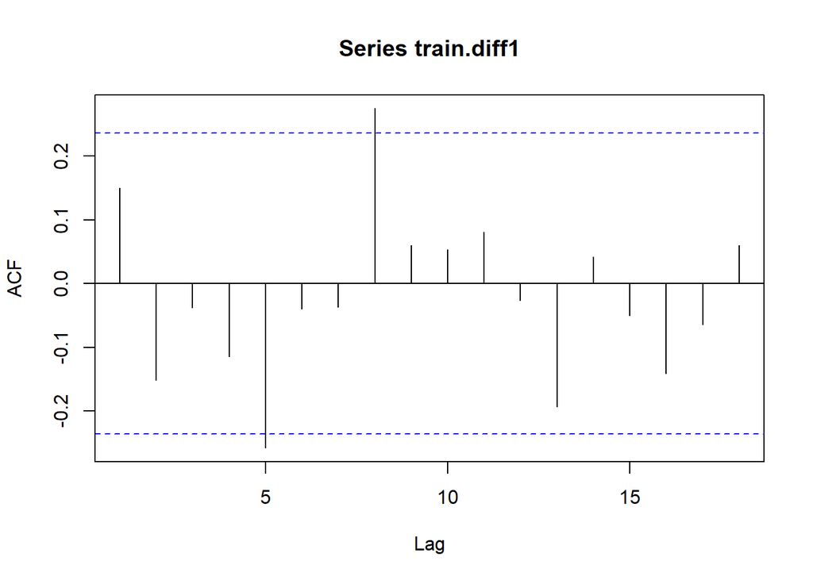

```r
acf(train.diff1)
```

Plot diatas tails off dengan pola membentuk gelombang sinus

### Plot PACF

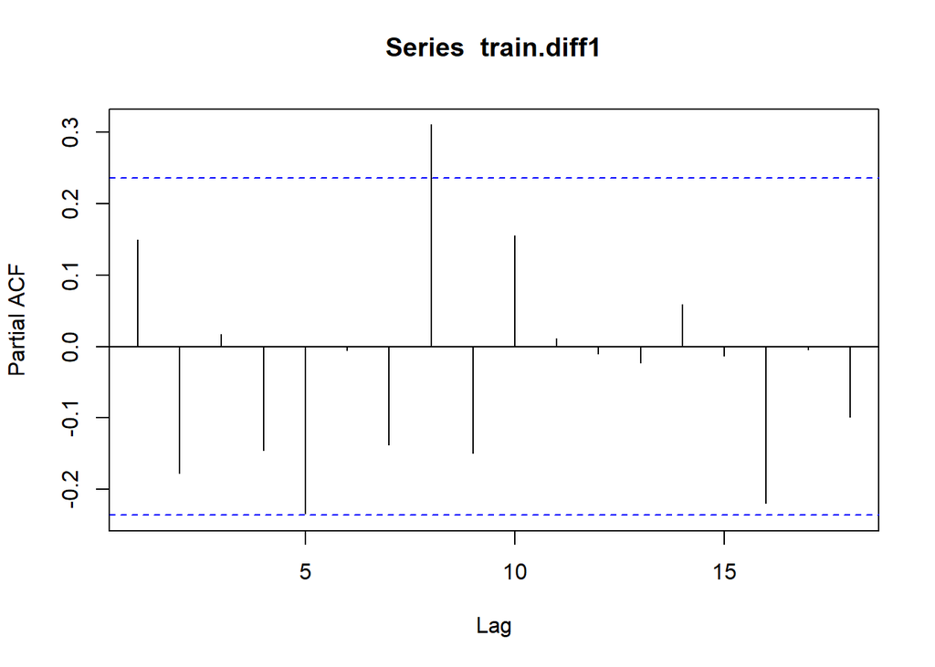

```r
pacf(train.diff1)
```

Plot diatas tails off dengan pola membentuk gelombang sinus

### Plot EACF

```r
eacf(train.diff1)
```

```
## AR/MA
##   0 1 2 3 4 5 6 7 8 9 10 11 12 13
## 0 o o o o x o o x o o o  o  o  o
## 1 x o o o x o o x o o o  o  o  o
## 2 o x o o o o o x o o o  o  o  o
## 3 o o o o o o o x o o o  o  o  o
## 4 x x x x o o o o o o o  o  o  o
## 5 o x x o o o o o o o o  o  o  o
## 6 o o o o o o o o o o o  o  o  o
## 7 o o x o o o o o o o o  o  o  o
```

Identifikasi model menggunakan plot menunjukkan model tentatif yang terbentuk adalah ARIMA (0,1,0), ARIMA (0,1,1),ARIMA (1,1,1), ARIMA (2,1,2), ARIMA (2,1,1)

### Pendugaan Parameter Model Tentatif

### ARIMA(0,1,0)

```r
model1.da=Arima(train.diff1, order=c(0,1,0),method="ML")
summary(model1.da) #AIC=603.92
```

```
## Series: train.diff1
## ARIMA(0,1,0)
##
## sigma^2 = 409.1:  log likelihood = -300.96
## AIC=603.92   AICc=603.98   BIC=606.14
##
## Training set error measures:
##                     ME     RMSE      MAE      MPE     MAPE      MASE       ACF1
## Training set -0.115784 20.07792 15.21697 294.7088 449.2978 0.9855175 -0.3205598
```

### ARIMA(1,1,1)

```r
model2.da=Arima(train.diff1, order=c(1,1,1),method="ML")
summary(model2.da) #AIC=574.74
```

```
## Series: train.diff1
## ARIMA(1,1,1)
##
## Coefficients:
##          ar1      ma1
##       0.1665  -1.0000
## s.e.  0.1211   0.0449
##
## sigma^2 = 244.3:  log likelihood = -284.37
## AIC=574.74   AICc=575.11   BIC=581.4
##
## Training set error measures:
##                      ME     RMSE      MAE      MPE     MAPE      MASE
## Training set -0.6837285 15.28611 11.51749 74.46153 99.26317 0.7459228
##                    ACF1
## Training set 0.02436553
```

```r
lmtest::coeftest(model2.da) #ar1 tidak signifikan
```

```
##
## z test of coefficients:
##
##      Estimate Std. Error  z value Pr(>|z|)
## ar1  0.166489   0.121073   1.3751   0.1691
## ma1 -0.999998   0.044896 -22.2736   <2e-16 ***
## ---
## Signif. codes:  0 '***' 0.001 '**' 0.01 '*' 0.05 '.' 0.1 ' ' 1
```

### ARIMA(2,1,2)

```r
model3.da=Arima(train.diff1, order=c(2,1,2),method="ML")
summary(model3.da) #AIC=576.76
```

```
## Series: train.diff1
## ARIMA(2,1,2)
##
## Coefficients:
##           ar1      ar2      ma1      ma2
##       -0.0520  -0.1247  -0.7527  -0.2473
## s.e.   0.4949   0.1561   0.4938   0.4915
##
## sigma^2 = 243.6:  log likelihood = -283.38
## AIC=576.76   AICc=577.73   BIC=587.86
##
## Training set error measures:
##                      ME     RMSE      MAE      MPE     MAPE      MASE
## Training set -0.5762028 15.03296 11.11083 85.63058 106.7474 0.7195857
##                      ACF1
## Training set -0.001964495
```

```r
lmtest::coeftest(model3.da) #seluruh parameter tidak signifikan
```

```
##
## z test of coefficients:
##
##      Estimate Std. Error z value Pr(>|z|)
## ar1 -0.051986   0.494928 -0.1050   0.9163
## ar2 -0.124689   0.156090 -0.7988   0.4244
## ma1 -0.752732   0.493818 -1.5243   0.1274
## ma2 -0.247256   0.491483 -0.5031   0.6149
```

### ARIMA(0,1,1)

```r
model4.da=Arima(train.diff1, order=c(0,1,1),method="ML")
summary(model4.da) #AIC=574.61
```

```
## Series: train.diff1
## ARIMA(0,1,1)
##
## Coefficients:
##           ma1
##       -1.0000
## s.e.   0.0515
##
## sigma^2 = 246.2:  log likelihood = -285.31
## AIC=574.61   AICc=574.8   BIC=579.05
##
## Training set error measures:
##                     ME     RMSE      MAE      MPE     MAPE   MASE      ACF1
## Training set -0.687721 15.46089 12.02667 27.10377 163.0636 0.7789 0.1621661
```

```r
lmtest::coeftest(model4.da)
```

```
##
## z test of coefficients:
##
##      Estimate Std. Error z value  Pr(>|z|)
## ma1 -1.000000   0.051538 -19.403 < 2.2e-16 ***
## ---
## Signif. codes:  0 '***' 0.001 '**' 0.01 '*' 0.05 '.' 0.1 ' ' 1
```

ARIMA(2,1,1)

```r
model5.da=Arima(train.diff1, order=c(2,1,1),method="ML")
summary(model5.da) #AIC=574.89
```

```
## Series: train.diff1
## ARIMA(2,1,1)
##
## Coefficients:
##          ar1      ar2      ma1
##       0.1880  -0.1640  -1.0000
## s.e.  0.1201   0.1195   0.0506
##
## sigma^2 = 240.1:  log likelihood = -283.45
## AIC=574.89   AICc=575.53   BIC=583.77
##
## Training set error measures:
##                      ME     RMSE     MAE      MPE     MAPE      MASE
## Training set -0.5735621 15.04026 11.1523 74.62764 95.57475 0.7222716
##                     ACF1
## Training set 0.001789925
```

```r
lmtest::coeftest(model5.da) #ar1 dan ar2 tidak signifikan
```

```
##
## z test of coefficients:
##
##      Estimate Std. Error  z value Pr(>|z|)
## ar1  0.187979   0.120134   1.5647   0.1176
## ar2 -0.164008   0.119452  -1.3730   0.1697
## ma1 -0.999999   0.050627 -19.7524   <2e-16 ***
## ---
## Signif. codes:  0 '***' 0.001 '**' 0.01 '*' 0.05 '.' 0.1 ' ' 1
```

Pendugaan parameter beberapa model tentatif di atas, menunjukkan nilai AIC terkecil dimiliki oleh model ARIMA(0,1,1) dengan seluruh parameter signifikan, sehingga model yang dipilih adalah model ARIMA(0,1,1).

### Analisis Sisaan

### Eksplorasi Sisaan

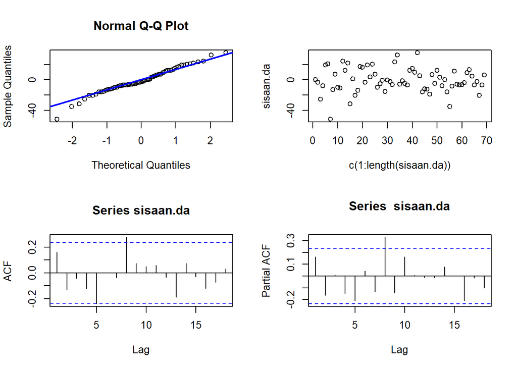

```r
#Eksplorasi
sisaan.da <- model4.da$residuals
par(mfrow=c(2,2))
qqnorm(sisaan.da)
qqline(sisaan.da, col = "blue", lwd = 2)
plot(c(1:length(sisaan.da)),sisaan.da)
acf(sisaan.da)
pacf(sisaan.da)
```

Berdasarkan QQ plot, secara eksplorasi ditunjukkan sisaan normal ditandai dengan titik titik yang cenderung mengikuti garis 45 derajat. Kemudian dapat dilihat juga lebar pita sisaan yang cenderung sama menandakan bahwa sisaan memiliki ragam yang homogen. Namun, Plot ACF dan PACF sisaan ARIMA(0,1,1) menunjukan signifikan pada lag 5 dan lag 8 yang menandakan tidak saling bebas. Kondisi ini akan diuji lebih lanjut dengan uji formal.